# A-quick-tour-of-SNMoE

# Introduction

**SNMoE** (Skew-Normal Mixtures-of-Experts) provides a flexible modelling framework for heterogenous data with possibly skewed distributions to generalize the standard Normal mixture of expert model. **SNMoE** consists of a mixture of *K* skew-Normal expert regressors network (of degree *p*) gated by a softmax gating network (of degree *q*) and is represented by:

- The gating network parameters `alpha`’s of the softmax net.
- The experts network parameters: The location parameters (regression coefficients) `beta`’s, scale parameters `sigma`’s, and the skewness parameters `lambda`’s. **SNMoE** thus generalises mixtures of (normal, skew-normal) distributions and mixtures of regressions with these distributions. For example, when $q=0$, we retrieve mixtures of (skew-normal, or normal) regressions, and when both $p=0$ and $q=0$, it is a mixture of (skew-normal, or normal) distributions. It also reduces to the standard (normal, skew-normal) distribution when we only use a single expert ($K=1$).

Model estimation/learning is performed by a dedicated expectation conditional maximization (ECM) algorithm by maximizing the observed data log-likelihood. We provide simulated examples to illustrate the use of the model in model-based clustering of heterogeneous regression data and in fitting non-linear regression functions.

It was written in R Markdown, using the knitr package for production.

See `help(package="meteorits")` for further details and references provided by `citation("meteorits")`.

# Application to a simulated dataset

## Generate sample

```r
n <- 500 # Size of the sample
alphak <- matrix(c(0, 8), ncol = 1) # Parameters of the gating network
betak <- matrix(c(0, -2.5, 0, 2.5), ncol = 2) # Regression coefficients of the experts
lambdak <- c(3, 5) # Skewness parameters of the experts
sigmak <- c(1, 1) # Standard deviations of the experts
x <- seq.int(from = -1, to = 1, length.out = n) # Inputs (predictors)

# Generate sample of size n
sample <- sampleUnivSNMoE(alphak = alphak, betak = betak, sigmak = sigmak,
                          lambdak = lambdak, x = x)
y <- sample$y
```

## Set up SNMoE model parameters

```r
K <- 2 # Number of regressors/experts
p <- 1 # Order of the polynomial regression (regressors/experts)
q <- 1 # Order of the logistic regression (gating network)
```

## Set up EM parameters

```r
n_tries <- 1
max_iter <- 1500
threshold <- 1e-6
verbose <- TRUE
verbose_IRLS <- FALSE
```

## Estimation

```r
snmoe <- emSNMoE(X = x, Y = y, K, p, q, n_tries, max_iter,
                 threshold, verbose, verbose_IRLS)
## EM - SNMoE: Iteration: 1 | log-likelihood: -656.585355371133
## EM - SNMoE: Iteration: 2 | log-likelihood: -555.851354544233
## EM - SNMoE: Iteration: 3 | log-likelihood: -550.40397615086
## EM - SNMoE: Iteration: 4 | log-likelihood: -548.256269199245
## EM - SNMoE: Iteration: 5 | log-likelihood: -546.79761691946
## EM - SNMoE: Iteration: 6 | log-likelihood: -545.498730796638
## EM - SNMoE: Iteration: 7 | log-likelihood: -544.229516949694
## EM - SNMoE: Iteration: 8 | log-likelihood: -542.958103085708
## EM - SNMoE: Iteration: 9 | log-likelihood: -541.681500704805
## EM - SNMoE: Iteration: 10 | log-likelihood: -540.407115609336
## EM - SNMoE: Iteration: 11 | log-likelihood: -539.146820343145
## EM - SNMoE: Iteration: 12 | log-likelihood: -537.913813832749
## EM - SNMoE: Iteration: 13 | log-likelihood: -536.720899008939
## EM - SNMoE: Iteration: 14 | log-likelihood: -535.579292897818
## EM - SNMoE: Iteration: 15 | log-likelihood: -534.497771291138
## EM - SNMoE: Iteration: 16 | log-likelihood: -533.482623881359
## EM - SNMoE: Iteration: 17 | log-likelihood: -532.537400886237
## EM - SNMoE: Iteration: 18 | log-likelihood: -531.663354290639
## EM - SNMoE: Iteration: 19 | log-likelihood: -530.859782849494
## EM - SNMoE: Iteration: 20 | log-likelihood: -530.124474505373
## EM - SNMoE: Iteration: 21 | log-likelihood: -529.454081457966
## EM - SNMoE: Iteration: 22 | log-likelihood: -528.844566438528
## EM - SNMoE: Iteration: 23 | log-likelihood: -528.291660433467
## EM - SNMoE: Iteration: 24 | log-likelihood: -527.790776101843
## EM - SNMoE: Iteration: 25 | log-likelihood: -527.337552677311
## EM - SNMoE: Iteration: 26 | log-likelihood: -526.927568557389
## EM - SNMoE: Iteration: 27 | log-likelihood: -526.556808002048
## EM - SNMoE: Iteration: 28 | log-likelihood: -526.221489868901
## EM - SNMoE: Iteration: 29 | log-likelihood: -525.918111169502
## EM - SNMoE: Iteration: 30 | log-likelihood: -525.643571977313
## EM - SNMoE: Iteration: 31 | log-likelihood: -525.394982295586
## EM - SNMoE: Iteration: 32 | log-likelihood: -525.169791442885
## EM - SNMoE: Iteration: 33 | log-likelihood: -524.965627851988
## EM - SNMoE: Iteration: 34 | log-likelihood: -524.780396186065
## EM - SNMoE: Iteration: 35 | log-likelihood: -524.612260461921
## EM - SNMoE: Iteration: 36 | log-likelihood: -524.459527851425
## EM - SNMoE: Iteration: 37 | log-likelihood: -524.320680968369
## EM - SNMoE: Iteration: 38 | log-likelihood: -524.194275811578
## EM - SNMoE: Iteration: 39 | log-likelihood: -524.079204577556
## EM - SNMoE: Iteration: 40 | log-likelihood: -523.974278677667
## EM - SNMoE: Iteration: 41 | log-likelihood: -523.878584007979
## EM - SNMoE: Iteration: 42 | log-likelihood: -523.79127103212
## EM - SNMoE: Iteration: 43 | log-likelihood: -523.711537505536
## EM - SNMoE: Iteration: 44 | log-likelihood: -523.638663861989
## EM - SNMoE: Iteration: 45 | log-likelihood: -523.572020616773
## EM - SNMoE: Iteration: 46 | log-likelihood: -523.51105683585
## EM - SNMoE: Iteration: 47 | log-likelihood: -523.45523763021
## EM - SNMoE: Iteration: 48 | log-likelihood: -523.404094820721
## EM - SNMoE: Iteration: 49 | log-likelihood: -523.357197899916
## EM - SNMoE: Iteration: 50 | log-likelihood: -523.314195116695
## EM - SNMoE: Iteration: 51 | log-likelihood: -523.274731350111
## EM - SNMoE: Iteration: 52 | log-likelihood: -523.238497282287
## EM - SNMoE: Iteration: 53 | log-likelihood: -523.20521117643
## EM - SNMoE: Iteration: 54 | log-likelihood: -523.174623420712
## EM - SNMoE: Iteration: 55 | log-likelihood: -523.14650921297
## EM - SNMoE: Iteration: 56 | log-likelihood: -523.120624949574
## EM - SNMoE: Iteration: 57 | log-likelihood: -523.096805165477
## EM - SNMoE: Iteration: 58 | log-likelihood: -523.074873128819
## EM - SNMoE: Iteration: 59 | log-likelihood: -523.054674240861
## EM - SNMoE: Iteration: 60 | log-likelihood: -523.03606316995
## EM - SNMoE: Iteration: 61 | log-likelihood: -523.018912105525
## EM - SNMoE: Iteration: 62 | log-likelihood: -523.003108239484
## EM - SNMoE: Iteration: 63 | log-likelihood: -522.988528530823
## EM - SNMoE: Iteration: 64 | log-likelihood: -522.975073821454
## EM - SNMoE: Iteration: 65 | log-likelihood: -522.962658116351
## EM - SNMoE: Iteration: 66 | log-likelihood: -522.951197729821
## EM - SNMoE: Iteration: 67 | log-likelihood: -522.940615053758
## EM - SNMoE: Iteration: 68 | log-likelihood: -522.930837323248
## EM - SNMoE: Iteration: 69 | log-likelihood: -522.921799670704
## EM - SNMoE: Iteration: 70 | log-likelihood: -522.913460449863
## EM - SNMoE: Iteration: 71 | log-likelihood: -522.905749029112
## EM - SNMoE: Iteration: 72 | log-likelihood: -522.898618215682
## EM - SNMoE: Iteration: 73 | log-likelihood: -522.892024064304
## EM - SNMoE: Iteration: 74 | log-likelihood: -522.885928152182
## EM - SNMoE: Iteration: 75 | log-likelihood: -522.880251651286
## EM - SNMoE: Iteration: 76 | log-likelihood: -522.875039802663
## EM - SNMoE: Iteration: 77 | log-likelihood: -522.870215420373
## EM - SNMoE: Iteration: 78 | log-likelihood: -522.865747017774
## EM - SNMoE: Iteration: 79 | log-likelihood: -522.861604068504
## EM - SNMoE: Iteration: 80 | log-likelihood: -522.857763457417
## EM - SNMoE: Iteration: 81 | log-likelihood: -522.854200761546
## EM - SNMoE: Iteration: 82 | log-likelihood: -522.850901973912
## EM - SNMoE: Iteration: 83 | log-likelihood: -522.847842210239
## EM - SNMoE: Iteration: 84 | log-likelihood: -522.844998980421
## EM - SNMoE: Iteration: 85 | log-likelihood: -522.84236087728
## EM - SNMoE: Iteration: 86 | log-likelihood: -522.83990035162
## EM - SNMoE: Iteration: 87 | log-likelihood: -522.837632371244
## EM - SNMoE: Iteration: 88 | log-likelihood: -522.835527816052
## EM - SNMoE: Iteration: 89 | log-likelihood: -522.833572884379
## EM - SNMoE: Iteration: 90 | log-likelihood: -522.83175632226
## EM - SNMoE: Iteration: 91 | log-likelihood: -522.830067784768
## EM - SNMoE: Iteration: 92 | log-likelihood: -522.828497770286
## EM - SNMoE: Iteration: 93 | log-likelihood: -522.827037535638
## EM - SNMoE: Iteration: 94 | log-likelihood: -522.825671743242
## EM - SNMoE: Iteration: 95 | log-likelihood: -522.824408018797
## EM - SNMoE: Iteration: 96 | log-likelihood: -522.823231562984
## EM - SNMoE: Iteration: 97 | log-likelihood: -522.822142806484
## EM - SNMoE: Iteration: 98 | log-likelihood: -522.821129548988
## EM - SNMoE: Iteration: 99 | log-likelihood: -522.820181902464
## EM - SNMoE: Iteration: 100 | log-likelihood: -522.819299479679
## EM - SNMoE: Iteration: 101 | log-likelihood: -522.818473570031
## EM - SNMoE: Iteration: 102 | log-likelihood: -522.817707344368
## EM - SNMoE: Iteration: 103 | log-likelihood: -522.816993085223
## EM - SNMoE: Iteration: 104 | log-likelihood: -522.816326718962
## EM - SNMoE: Iteration: 105 | log-likelihood: -522.815703759307
## EM - SNMoE: Iteration: 106 | log-likelihood: -522.815122562169
## EM - SNMoE: Iteration: 107 | log-likelihood: -522.814582615201
## EM - SNMoE: Iteration: 108 | log-likelihood: -522.814077443441
```

## Summary

```r
snmoe$summary()
```

```
## -----------------------------------------------
## Fitted Skew-Normal Mixture-of-Experts model
## -----------------------------------------------
##
## SNMoE model with K = 2 experts:
##
##  log-likelihood df       AIC       BIC       ICL
##       -522.8141 10 -532.8141 -553.8871 -553.8946
##
## Clustering table (Number of observations in each expert):
##
##   1   2
## 249 251
##
## Regression coefficients:
##
##     Beta(k = 1) Beta(k = 2)
## 1     0.1643449    1.030347
## X^1   2.7624124   -2.713522
##
## Variances:
##
##  Sigma2(k = 1) Sigma2(k = 2)
##       1.130847     0.6125231
```

## Plots

### Mean curve

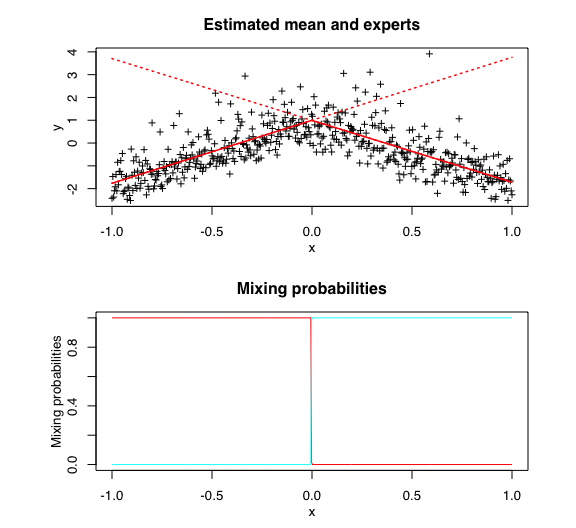

```r
snmoe$plot(what = "meancurve")
```

### Confidence regions

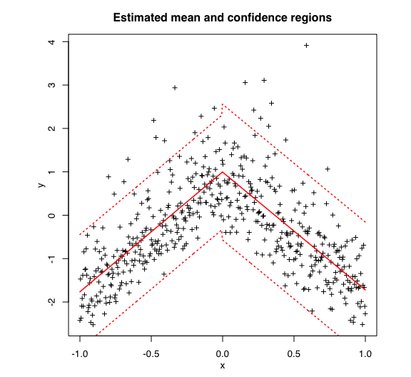

```r
snmoe$plot(what = "confregions")
```

### Clusters

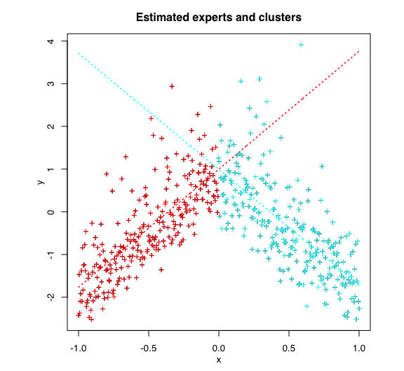

```r
snmoe$plot(what = "clusters")
```

### Log-likelihood

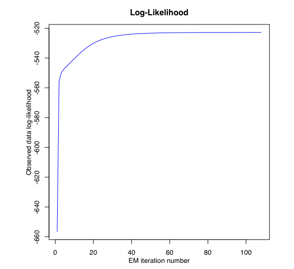

```r
snmoe$plot(what = "loglikelihood")
```

# Application to a real dataset

## Load data

```r
data("tempanomalies")
x <- tempanomalies$Year
y <- tempanomalies$AnnualAnomaly
```

## Set up SNMoE model parameters

```r
K <- 2 # Number of regressors/experts
p <- 1 # Order of the polynomial regression (regressors/experts)
q <- 1 # Order of the logistic regression (gating network)
```

## Set up EM parameters

```r
n_tries <- 1
max_iter <- 1500
threshold <- 1e-6
verbose <- TRUE
verbose_IRLS <- FALSE
```

## Estimation

```r
snmoe <- emSNMoE(X = x, Y = y, K, p, q, n_tries, max_iter,
                 threshold, verbose, verbose_IRLS)
## EM - SNMoE: Iteration: 1 | log-likelihood: 61.8107860891512
## EM - SNMoE: Iteration: 2 | log-likelihood: 87.653433029568
## EM - SNMoE: Iteration: 3 | log-likelihood: 88.8833709628339
## EM - SNMoE: Iteration: 4 | log-likelihood: 89.2593088472611
## EM - SNMoE: Iteration: 5 | log-likelihood: 89.5213488387829
## EM - SNMoE: Iteration: 6 | log-likelihood: 89.7275294002096
## EM - SNMoE: Iteration: 7 | log-likelihood: 89.8478728949139
## EM - SNMoE: Iteration: 8 | log-likelihood: 89.9133766120692
## EM - SNMoE: Iteration: 9 | log-likelihood: 89.9496067667942
## EM - SNMoE: Iteration: 10 | log-likelihood: 89.972407680618
## EM - SNMoE: Iteration: 11 | log-likelihood: 89.9899191229059
## EM - SNMoE: Iteration: 12 | log-likelihood: 90.004975878789
## EM - SNMoE: Iteration: 13 | log-likelihood: 90.0183693239978
## EM - SNMoE: Iteration: 14 | log-likelihood: 90.0306979505493
## EM - SNMoE: Iteration: 15 | log-likelihood: 90.0423279583216
## EM - SNMoE: Iteration: 16 | log-likelihood: 90.0534008186115
## EM - SNMoE: Iteration: 17 | log-likelihood: 90.0639652852913
## EM - SNMoE: Iteration: 18 | log-likelihood: 90.0740391463467
## EM - SNMoE: Iteration: 19 | log-likelihood: 90.0836351937132
## EM - SNMoE: Iteration: 20 | log-likelihood: 90.0927642445026
## EM - SNMoE: Iteration: 21 | log-likelihood: 90.1014354198911
## EM - SNMoE: Iteration: 22 | log-likelihood: 90.1097361300989
## EM - SNMoE: Iteration: 23 | log-likelihood: 90.1177206846869
## EM - SNMoE: Iteration: 24 | log-likelihood: 90.1252833934951
## EM - SNMoE: Iteration: 25 | log-likelihood: 90.1324643650817
## EM - SNMoE: Iteration: 26 | log-likelihood: 90.139292672088
## EM - SNMoE: Iteration: 27 | log-likelihood: 90.1459728264202
## EM - SNMoE: Iteration: 28 | log-likelihood: 90.1516060147328
## EM - SNMoE: Iteration: 29 | log-likelihood: 90.1576539826842
## EM - SNMoE: Iteration: 30 | log-likelihood: 90.1633562391825
## EM - SNMoE: Iteration: 31 | log-likelihood: 90.1690576322968
## EM - SNMoE: Iteration: 32 | log-likelihood: 90.1746997496675
## EM - SNMoE: Iteration: 33 | log-likelihood: 90.1806424690734
## EM - SNMoE: Iteration: 34 | log-likelihood: 90.1862798587024
## EM - SNMoE: Iteration: 35 | log-likelihood: 90.1919478880309
## EM - SNMoE: Iteration: 36 | log-likelihood: 90.1976099836365
## EM - SNMoE: Iteration: 37 | log-likelihood: 90.203561455103
## EM - SNMoE: Iteration: 38 | log-likelihood: 90.2093875353642
## EM - SNMoE: Iteration: 39 | log-likelihood: 90.2153969391873
## EM - SNMoE: Iteration: 40 | log-likelihood: 90.2214374426839
## EM - SNMoE: Iteration: 41 | log-likelihood: 90.227541806096
## EM - SNMoE: Iteration: 42 | log-likelihood: 90.2337415516567
## EM - SNMoE: Iteration: 43 | log-likelihood: 90.2400039100493
## EM - SNMoE: Iteration: 44 | log-likelihood: 90.2463513808701
## EM - SNMoE: Iteration: 45 | log-likelihood: 90.2527816784661
## EM - SNMoE: Iteration: 46 | log-likelihood: 90.2592937999795
## EM - SNMoE: Iteration: 47 | log-likelihood: 90.2658827438485
## EM - SNMoE: Iteration: 48 | log-likelihood: 90.2725441439769
## EM - SNMoE: Iteration: 49 | log-likelihood: 90.2792759199145
## EM - SNMoE: Iteration: 50 | log-likelihood: 90.2860735395109
## EM - SNMoE: Iteration: 51 | log-likelihood: 90.2929334241878
## EM - SNMoE: Iteration: 52 | log-likelihood: 90.2998533907677
## EM - SNMoE: Iteration: 53 | log-likelihood: 90.3068307807613
## EM - SNMoE: Iteration: 54 | log-likelihood: 90.3138605732987
## EM - SNMoE: Iteration: 55 | log-likelihood: 90.3209357858695
## EM - SNMoE: Iteration: 56 | log-likelihood: 90.328048991458
## EM - SNMoE: Iteration: 57 | log-likelihood: 90.3352024024446
## EM - SNMoE: Iteration: 58 | log-likelihood: 90.3423855597436
## EM - SNMoE: Iteration: 59 | log-likelihood: 90.3495924437094
## EM - SNMoE: Iteration: 60 | log-likelihood: 90.3568261203392
## EM - SNMoE: Iteration: 61 | log-likelihood: 90.3640748459131
## EM - SNMoE: Iteration: 62 | log-likelihood: 90.371333215756
## EM - SNMoE: Iteration: 63 | log-likelihood: 90.3785974198304
## EM - SNMoE: Iteration: 64 | log-likelihood: 90.3858673527619
## EM - SNMoE: Iteration: 65 | log-likelihood: 90.3931292714727
## EM - SNMoE: Iteration: 66 | log-likelihood: 90.4003836899496
## EM - SNMoE: Iteration: 67 | log-likelihood: 90.4076267388457
## EM - SNMoE: Iteration: 68 | log-likelihood: 90.4148529472172
## EM - SNMoE: Iteration: 69 | log-likelihood: 90.4220415457928
## EM - SNMoE: Iteration: 70 | log-likelihood: 90.4292227942202
## EM - SNMoE: Iteration: 71 | log-likelihood: 90.4363615399269
## EM - SNMoE: Iteration: 72 | log-likelihood: 90.44348118438
## EM - SNMoE: Iteration: 73 | log-likelihood: 90.4505423602557
## EM - SNMoE: Iteration: 74 | log-likelihood: 90.4575736947274
## EM - SNMoE: Iteration: 75 | log-likelihood: 90.4645317698077
## EM - SNMoE: Iteration: 76 | log-likelihood: 90.471441135118
## EM - SNMoE: Iteration: 77 | log-likelihood: 90.4783363924479
## EM - SNMoE: Iteration: 78 | log-likelihood: 90.485169104714
## EM - SNMoE: Iteration: 79 | log-likelihood: 90.4919851201156
## EM - SNMoE: Iteration: 80 | log-likelihood: 90.4987630599154
## EM - SNMoE: Iteration: 81 | log-likelihood: 90.505498020851
## EM - SNMoE: Iteration: 82 | log-likelihood: 90.5121880230423
## EM - SNMoE: Iteration: 83 | log-likelihood: 90.5188317031798
## EM - SNMoE: Iteration: 84 | log-likelihood: 90.5254271130459
## EM - SNMoE: Iteration: 85 | log-likelihood: 90.5319679151838
## EM - SNMoE: Iteration: 86 | log-likelihood: 90.5384580238327
## EM - SNMoE: Iteration: 87 | log-likelihood: 90.54489570749
## EM - SNMoE: Iteration: 88 | log-likelihood: 90.5512787332165
## EM - SNMoE: Iteration: 89 | log-likelihood: 90.5576056329805
## EM - SNMoE: Iteration: 90 | log-likelihood: 90.5638759536621
## EM - SNMoE: Iteration: 91 | log-likelihood: 90.5700851096825
## EM - SNMoE: Iteration: 92 | log-likelihood: 90.5762332093015
## EM - SNMoE: Iteration: 93 | log-likelihood: 90.5823201189998
## EM - SNMoE: Iteration: 94 | log-likelihood: 90.5883447356442
## EM - SNMoE: Iteration: 95 | log-likelihood: 90.5943108744181
## EM - SNMoE: Iteration: 96 | log-likelihood: 90.6002108887989
## EM - SNMoE: Iteration: 97 | log-likelihood: 90.6060457917246
## EM - SNMoE: Iteration: 98 | log-likelihood: 90.6118155982874
## EM - SNMoE: Iteration: 99 | log-likelihood: 90.6175199754286
## EM - SNMoE: Iteration: 100 | log-likelihood: 90.6231585860668
## EM - SNMoE: Iteration: 101 | log-likelihood: 90.6287325025507
## EM - SNMoE: Iteration: 102 | log-likelihood: 90.6342408576653
## EM - SNMoE: Iteration: 103 | log-likelihood: 90.6396830114749
## EM - SNMoE: Iteration: 104 | log-likelihood: 90.6450584380143
## EM - SNMoE: Iteration: 105 | log-likelihood: 90.6503666930602
## EM - SNMoE: Iteration: 106 | log-likelihood: 90.6556073435694
## EM - SNMoE: Iteration: 107 | log-likelihood: 90.6607800599078
## EM - SNMoE: Iteration: 108 | log-likelihood: 90.6658845701878
## EM - SNMoE: Iteration: 109 | log-likelihood: 90.6709241089268
## EM - SNMoE: Iteration: 110 | log-likelihood: 90.6758901590132
## EM - SNMoE: Iteration: 111 | log-likelihood: 90.6807864913494
## EM - SNMoE: Iteration: 112 | log-likelihood: 90.6856126351101
## EM - SNMoE: Iteration: 113 | log-likelihood: 90.6903674816091
## EM - SNMoE: Iteration: 114 | log-likelihood: 90.6950498349074
## EM - SNMoE: Iteration: 115 | log-likelihood: 90.6996585549005
## EM - SNMoE: Iteration: 116 | log-likelihood: 90.7041879950612
## EM - SNMoE: Iteration: 117 | log-likelihood: 90.7086454128337
## EM - SNMoE: Iteration: 118 | log-likelihood: 90.7130246384314
## EM - SNMoE: Iteration: 119 | log-likelihood: 90.7173235558353
## EM - SNMoE: Iteration: 120 | log-likelihood: 90.7215404302965
## EM - SNMoE: Iteration: 121 | log-likelihood: 90.7256734677775
## EM - SNMoE: Iteration: 122 | log-likelihood: 90.7297185772278
## EM - SNMoE: Iteration: 123 | log-likelihood: 90.7336769649012
## EM - SNMoE: Iteration: 124 | log-likelihood: 90.7375605033218
## EM - SNMoE: Iteration: 125 | log-likelihood: 90.7413581408073
## EM - SNMoE: Iteration: 126 | log-likelihood: 90.7450648763976
## EM - SNMoE: Iteration: 127 | log-likelihood: 90.7486747427911
## EM - SNMoE: Iteration: 128 | log-likelihood: 90.7521857322021
## EM - SNMoE: Iteration: 129 | log-likelihood: 90.7555952617597
## EM - SNMoE: Iteration: 130 | log-likelihood: 90.7589802664455
## EM - SNMoE: Iteration: 131 | log-likelihood: 90.762004839102
## EM - SNMoE: Iteration: 132 | log-likelihood: 90.7652462466627
## EM - SNMoE: Iteration: 133 | log-likelihood: 90.7681067443209
## EM - SNMoE: Iteration: 134 | log-likelihood: 90.7709330515654
## EM - SNMoE: Iteration: 135 | log-likelihood: 90.7736872468889
## EM - SNMoE: Iteration: 136 | log-likelihood: 90.7763415878892
## EM - SNMoE: Iteration: 137 | log-likelihood: 90.7788885785095
## EM - SNMoE: Iteration: 138 | log-likelihood: 90.781369800045
## EM - SNMoE: Iteration: 139 | log-likelihood: 90.783756055558
## EM - SNMoE: Iteration: 140 | log-likelihood: 90.7860456545933
## EM - SNMoE: Iteration: 141 | log-likelihood: 90.7882481017574
## EM - SNMoE: Iteration: 142 | log-likelihood: 90.7903711308911
## EM - SNMoE: Iteration: 143 | log-likelihood: 90.7924158683177
## EM - SNMoE: Iteration: 144 | log-likelihood: 90.7945727995176
## EM - SNMoE: Iteration: 145 | log-likelihood: 90.7964419196681
## EM - SNMoE: Iteration: 146 | log-likelihood: 90.7982392203427
## EM - SNMoE: Iteration: 147 | log-likelihood: 90.799987894007
## EM - SNMoE: Iteration: 148 | log-likelihood: 90.8016440455661
## EM - SNMoE: Iteration: 149 | log-likelihood: 90.803244970535
## EM - SNMoE: Iteration: 150 | log-likelihood: 90.8047793659118
## EM - SNMoE: Iteration: 151 | log-likelihood: 90.8062400172524
## EM - SNMoE: Iteration: 152 | log-likelihood: 90.8076392301433
## EM - SNMoE: Iteration: 153 | log-likelihood: 90.8089796301606
## EM - SNMoE: Iteration: 154 | log-likelihood: 90.8102630312125
## EM - SNMoE: Iteration: 155 | log-likelihood: 90.8114912378714
## EM - SNMoE: Iteration: 156 | log-likelihood: 90.81266603702
## EM - SNMoE: Iteration: 157 | log-likelihood: 90.8139002935161
## EM - SNMoE: Iteration: 158 | log-likelihood: 90.8149676875867
## EM - SNMoE: Iteration: 159 | log-likelihood: 90.8159873005135
## EM - SNMoE: Iteration: 160 | log-likelihood: 90.8169609711228
## EM - SNMoE: Iteration: 161 | log-likelihood: 90.817890423814
## EM - SNMoE: Iteration: 162 | log-likelihood: 90.8187931229132
## EM - SNMoE: Iteration: 163 | log-likelihood: 90.8196380819641
## EM - SNMoE: Iteration: 164 | log-likelihood: 90.8204518556679
## EM - SNMoE: Iteration: 165 | log-likelihood: 90.821219422153
## EM - SNMoE: Iteration: 166 | log-likelihood: 90.8219570333579
## EM - SNMoE: Iteration: 167 | log-likelihood: 90.8226555970784
## EM - SNMoE: Iteration: 168 | log-likelihood: 90.8233188520901
## EM - SNMoE: Iteration: 169 | log-likelihood: 90.8239503919047
## EM - SNMoE: Iteration: 170 | log-likelihood: 90.8245515685013
## EM - SNMoE: Iteration: 171 | log-likelihood: 90.8251239839533
## EM - SNMoE: Iteration: 172 | log-likelihood: 90.8256690003121
## EM - SNMoE: Iteration: 173 | log-likelihood: 90.8261878084732
## EM - SNMoE: Iteration: 174 | log-likelihood: 90.8267438933268
## EM - SNMoE: Iteration: 175 | log-likelihood: 90.8272119529069
## EM - SNMoE: Iteration: 176 | log-likelihood: 90.8276542638926
## EM - SNMoE: Iteration: 177 | log-likelihood: 90.8280107080239
## EM - SNMoE: Iteration: 178 | log-likelihood: 90.8284939649173
## EM - SNMoE: Iteration: 179 | log-likelihood: 90.8288527776589
## EM - SNMoE: Iteration: 180 | log-likelihood: 90.8292220806304
## EM - SNMoE: Iteration: 181 | log-likelihood: 90.8295633025039
## EM - SNMoE: Iteration: 182 | log-likelihood: 90.8298873107783
## EM - SNMoE: Iteration: 183 | log-likelihood: 90.8302047282032
## EM - SNMoE: Iteration: 184 | log-likelihood: 90.8304964386323
## EM - SNMoE: Iteration: 185 | log-likelihood: 90.8307733087526
```

```r
## EM - SNMoE: Iteration: 186 | log-likelihood: 90.8310360569017
## EM - SNMoE: Iteration: 187 | log-likelihood: 90.8312853671496
## EM - SNMoE: Iteration: 188 | log-likelihood: 90.8315218931287
## EM - SNMoE: Iteration: 189 | log-likelihood: 90.8317462589012
## EM - SNMoE: Iteration: 190 | log-likelihood: 90.8319590599853
## EM - SNMoE: Iteration: 191 | log-likelihood: 90.8321608643629
## EM - SNMoE: Iteration: 192 | log-likelihood: 90.83235221346
## EM - SNMoE: Iteration: 193 | log-likelihood: 90.8325336231233
## EM - SNMoE: Iteration: 194 | log-likelihood: 90.8327055941627
## EM - SNMoE: Iteration: 195 | log-likelihood: 90.8329125906151
## EM - SNMoE: Iteration: 196 | log-likelihood: 90.8330665084005
## EM - SNMoE: Iteration: 197 | log-likelihood: 90.8331681272115
## EM - SNMoE: Iteration: 198 | log-likelihood: 90.8333513395607
## EM - SNMoE: Iteration: 199 | log-likelihood: 90.8334823518607
## EM - SNMoE: Iteration: 200 | log-likelihood: 90.8335619566083
```

## Summary

```r
snmoe$summary()
```

```
## -----------------------------------------------
## Fitted Skew-Normal Mixture-of-Experts model
## -----------------------------------------------
##
## SNMoE model with K = 2 experts:
##
##  log-likelihood df      AIC      BIC      ICL
##        90.83356 10 80.83356 66.27029 66.16225
##
## Clustering table (Number of observations in each expert):
##
##  1  2
## 69 67
##
## Regression coefficients:
##
##       Beta(k = 1) Beta(k = 2)
## 1   -14.428214634 -32.6510585
## X^1   0.007366202   0.0166957
##
## Variances:
##
##  Sigma2(k = 1) Sigma2(k = 2)
##     0.01816954    0.03712389
```

## Plots

### Mean curve

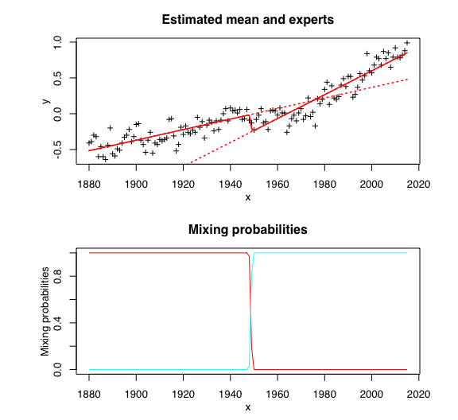

```r
snmoe$plot(what = "meancurve")
```

### Confidence regions

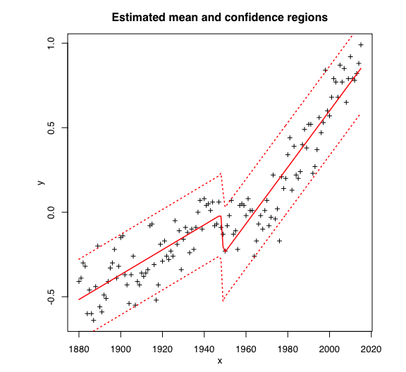

```r
snmoe$plot(what = "confregions")
```

### Clusters

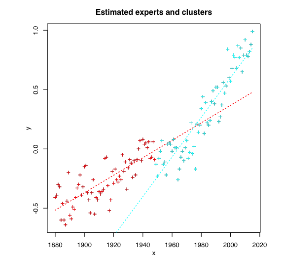

```r
snmoe$plot(what = "clusters")
```

### Log-likelihood

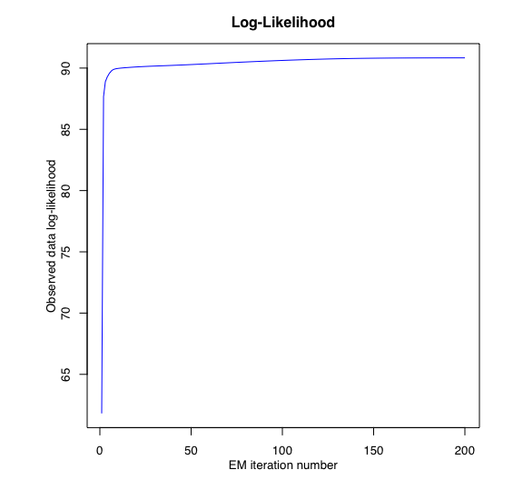

```r
snmoe$plot(what = "loglikelihood")
```